# DoD Acquisition Workforce Trends

# Model Summary

Navigation

Select a section to view.

Observations

233,119

Selected Model

Bidirectional Selection (Stepwise)

R-squared

0.562

Model explains 56% of salary variance

BIC

2,016,280

Predictors (8)

LOSLVL SUPERVIS DATECODE EDLVL AGY LOS AGELVL LOC

Selection Method

Direction: **both** Penalty: **k = log(n)** Response: **SALARY / 1000**

| Model | RMSE | MAE | Adj R2 |
| --- | --- | --- | --- |
| Bidirectional Selection (Stepwise) | 18.27 | 14.09 | 0.5624 |
| Simple (LOS + AGELVL + EDLVL) | 22.34 | 17.38 | 0.3458 |
| Swap: LOSLVL instead of LOS | 21.75 | 16.75 | 0.3801 |
| Swap: AGY instead of AGELVL | 22.23 | 17.25 | 0.3523 |
| Swap: EDLVL + EDLVL² | 22.33 | 17.38 | 0.3467 |
| Swap: LOSLVL + AGY + EDLVL² | 21.58 | 16.61 | 0.3897 |

What was done

Six models were estimated on federal employment salary data and evaluated using 10-fold cross-validation (3 repeats). The **Bidirection Selection (Stepwise)** model was selected via bidirectional stepwise regression penalised by `k = log(n)`. The remaining rows test whether swapping individual predictors improves out-of-sample performance over the simple three-variable baseline.

Reading the table

**RMSE** penalises large errors heavily, lower is better. **MAE** gives the average absolute miss in thousands of dollars. **Adj R²** is the share of salary variance explained out-of-sample. The green row is the best-performing model by RMSE.

What this model tells us

This model estimates what a federal civilian employee should expect to earn based on factors like education, years of service, age, and agency. Once the model is built, we can compare its predictions against what employees actually earn. Employees or agencies where actual pay consistently exceeds the prediction may be paying above what their workforce characteristics would typically justify. We use this approach to identify which DoD components; Army, Navy, Air Force, or DoD Other, pay their civilian employees more or less than the department average after accounting for those background factors.

# Residual Analysis

**Residual Analysis** — Residuals (Actual minus Predicted) reveal where the model succeeds and where it struggles. Ideally residuals are centred at zero with symmetric spread and no systematic patterns across agencies or salary levels.

### Residual Distribution

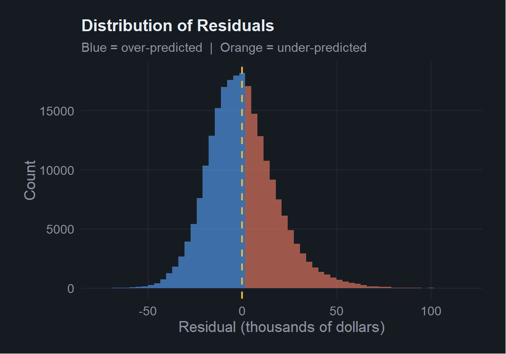

### Predicted vs. Actual

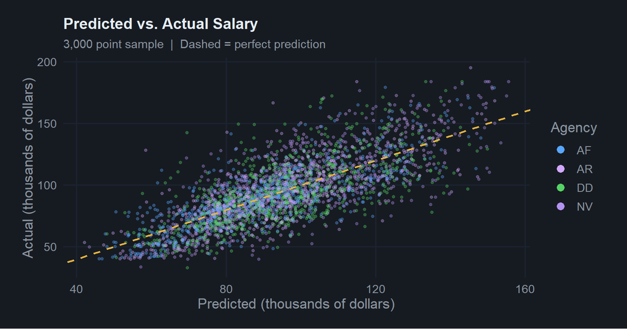